# Carseats And Tidy

brkuzn

05 06 2021

#1 Variables (GDPpc, RGDPpc, GDPpc_USD and population) are in the rows in “data2010.xls” and “data2015.xls”. Data sets should contain province, id, year, GDPpc, RGDPpc, GDPpc_USD and population in the columns

```r
library(readxl)
library(tidyverse)
library(tidyr)
data2010 <- read_excel("data2010.xls")
data2010
```

```
## # A tibble: 12 x 4
##    province    id variable   y2010
##    <chr>    <dbl> <chr>      <chr>
##  1 Istanbul    34 GDPpc      26253
##  2 Istanbul    34 RGDPpc     14384
##  3 Istanbul    34 GDPpc_USD  17480
##  4 Istanbul    34 population 13100000
##  5 Izmir       35 GDPpc      18308
##  6 Izmir       35 RGDPpc     10211.2
##  7 Izmir       35 GDPpc_USD  12190
##  8 Izmir       35 population 3908672
##  9 Ankara       6 GDPpc      23997
## 10 Ankara       6 RGDPpc     13018.7
## 11 Ankara       6 GDPpc_USD  15978
## 12 Ankara       6 population 4711187
```

```r
data2010_manipultd <- pivot_wider(data2010, names_from = variable, values_from = y2010)
data2010_manipultd
```

```
## # A tibble: 3 x 6
##   province    id GDPpc RGDPpc  GDPpc_USD population
##   <chr>    <dbl> <chr> <chr>   <chr>     <chr>
## 1 Istanbul    34 26253 14384   17480     13100000
## 2 Izmir       35 18308 10211.2 12190     3908672
## 3 Ankara       6 23997 13018.7 15978     4711187
```

```r
#2015
data2015 <- read_excel("data2015.xls")
head(data2015)
```

```
## # A tibble: 6 x 4
##   province    id variable   y2015
##   <chr>    <dbl> <chr>      <chr>
## 1 Istanbul    34 GDPpc      49773
## 2 Istanbul    34 RGDPpc     18601.5
## 3 Istanbul    34 GDPpc_USD  18343
## 4 Istanbul    34 population 14500000
## 5 Izmir       35 GDPpc      34261
## 6 Izmir       35 RGDPpc     12926.7
```

```r
data2015_manipultd <- pivot_wider(data2015, names_from = variable, values_from = y2015)
data2015_manipultd
```

```
## # A tibble: 3 x 6
##   province    id GDPpc RGDPpc  GDPpc_USD population
##   <chr>    <dbl> <chr> <chr>   <chr>     <chr>
## 1 Istanbul    34 49773 18601.5 18343     14500000
## 2 Izmir       35 34261 12926.7 12626     4140726
## 3 Ankara       6 40679 15029.1 14992     5210297
```

#2 we want to estimate a regression tree using `Sales` in Carseats dataset as the quantitative response variable. Do the following:

1. Split the data set into train and test sets (half-half). Using only the train data, fit a decision tree and plot. What is the test MSE?
2. Using CV, determine the optimal level of tree complexity. Based on the pruned tree, compute the test MSE and compare to the previous part.

```r
library(ISLR)
library(tree)
set.seed(123)
traindata <- sample(1:nrow(Carseats), nrow(Carseats)/2)
car_train <- Carseats[traindata, ]
car_test <- Carseats[-traindata, ]

tree1 <- tree(Sales ~ ., data = car_train)
summary(tree1)
```

```
##
## Regression tree:
## tree(formula = Sales ~ ., data = car_train)
## Variables actually used in tree construction:
## [1] "ShelveLoc"   "Price"       "Income"      "Age"         "Population"
## [6] "Education"   "CompPrice"   "Advertising"
## Number of terminal nodes:  18
## Residual mean deviance:  2.132 = 388.1 / 182
## Distribution of residuals:
##     Min.  1st Qu.   Median     Mean  3rd Qu.     Max.
## -4.08000 -0.92870  0.06244  0.00000  0.87020  3.71700
```

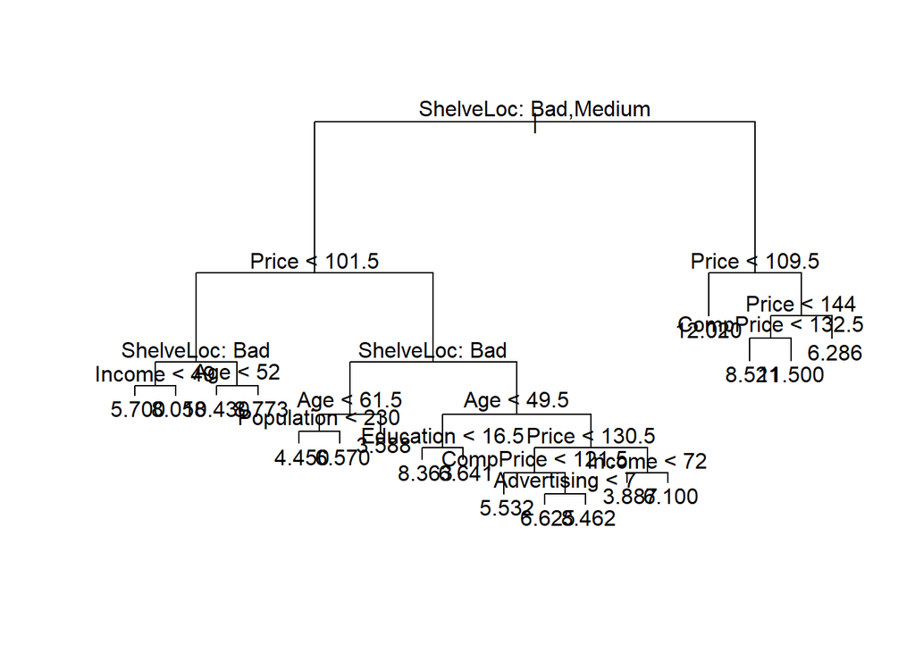

```r
plot(tree1)
text(tree1, pretty = 0)
```

```r
pred1 <- predict(tree1, newdata = car_test)
mean((pred1 - car_test$Sales)^2)
```

```
## [1] 4.395357
```

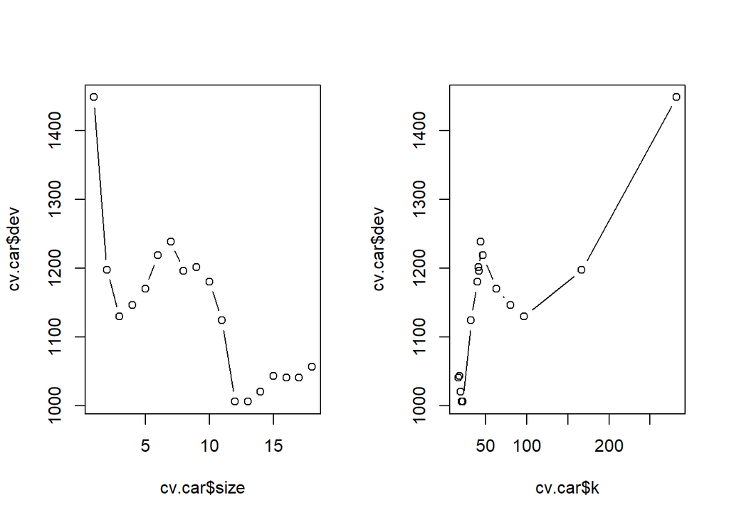

```r
#MSE is 4.395357.
#b
set.seed(100)
cv.car <- cv.tree(tree1)
par(mfrow = c(1, 2))
plot(cv.car$size, cv.car$dev, type = "b")
plot(cv.car$k, cv.car$dev, type = "b")
```

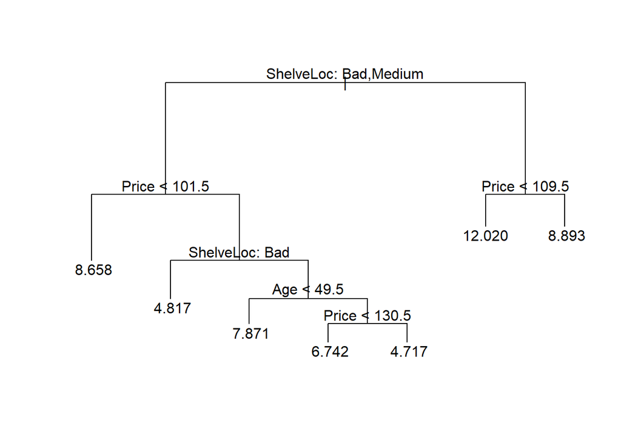

```r
par(mfrow = c(1,1))


pr1 <- prune.tree(tree1, best = 7)
plot(pr1)
text(pr1, pretty = 0)
```

```r
pred.prune <- predict(pr1, newdata = car_test)
mean((pred.prune - car_test$Sales)^2)
```

```
## [1] 4.696596
```

```r
#MSE was slightly higher after pruning, we can say that it was slightly better in the first case.(MSE = 4.696596)
```

#3 Continue using the data set from the previous question. This time,

1. Apply the bagging approach to estimate the decision tree. Compute the test MSE. Plot the variable importance graph and interpret.
2. Apply the random forest approach to estimate the decision tree. Compute the test MSE. How did you choose the number of variables considered at each split (mtry)? Plot the variable importance graph and interpret.

```r
library(randomForest)
set.seed(3)
airbag <- randomForest(Sales ~ ., data = Carseats, subset = traindata, mtry = 10,
                        importance = TRUE)
predbag <- predict(airbag, newdata = car_test)
mean((predbag - car_test$Sales)^2)
```

```
## [1] 2.755493
```

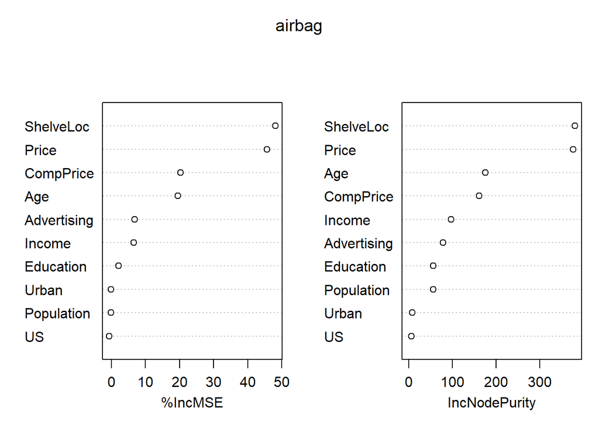

```r
varImpPlot(airbag)
```

```r
importance(airbag)
```

```
##                 %IncMSE IncNodePurity
## CompPrice   20.37033834    161.461267
## Income       6.60057434     97.038812
## Advertising  6.79522142     78.707851
## Population  -0.02514253     55.848016
## Price       45.71517361    377.078070
## ShelveLoc   48.19120372    380.862204
## Age         19.51665637    175.564056
## Education    2.20255573     56.164321
## Urban       -0.02244479      8.380252
## US          -0.61358651      6.729343
```

```r
#Pricing of a competitive company in the same region is important. Age, income and advertising are also important, but the most important predictors are shelving location of car seats and price.



# Let's check the MSEs for each split.



set.seed(3)

airbag1 <- randomForest(Sales ~ ., data = Carseats, subset = traindata, mtry = 1,
                        importance = TRUE)

predbag1 <- predict(airbag1, newdata = car_test)
mean((predbag1 - car_test$Sales)^2)
```

```
## [1] 5.269972
```

```r
set.seed(3)
airbag2 <- randomForest(Sales ~ ., data = Carseats, subset = traindata, mtry = 2,
                        importance = TRUE)

predbag2 <- predict(airbag2, newdata = car_test)
mean((predbag2- car_test$Sales)^2)
```

```
## [1] 4.10896
```

```r
set.seed(3)
airbag3 <- randomForest(Sales ~ ., data = Carseats, subset = traindata, mtry = 3,
                       importance = TRUE)

predbag3 <- predict(airbag3, newdata = car_test)
mean((predbag3 - car_test$Sales)^2)
```

```
## [1] 3.546194
```

```r
set.seed(3)
airbag4 <- randomForest(Sales ~ ., data = Carseats, subset = traindata, mtry = 4,
                        importance = TRUE)

predbag4 <- predict(airbag4, newdata = car_test)
mean((predbag4 - car_test$Sales)^2)
```

```
## [1] 3.26999
```

```r
set.seed(3)
airbag5 <- randomForest(Sales ~ ., data = Carseats, subset = traindata, mtry = 5,
                        importance = TRUE)

predbag5 <- predict(airbag5, newdata = car_test)
mean((predbag5 - car_test$Sales)^2)
```

```
## [1] 3.070315
```

```r
set.seed(3)
airbag6 <- randomForest(Sales ~ ., data = Carseats, subset = traindata, mtry = 6,
                        importance = TRUE)

predbag6 <-predict(airbag6, newdata = car_test)
mean((predbag6 - car_test$Sales)^2)
```

```
## [1] 2.977468
```

```r
set.seed(3)
airbag7 <- randomForest(Sales ~ ., data = Carseats, subset = traindata, mtry = 7,
                        importance = TRUE)

predbag7 <-predict(airbag7, newdata = car_test)
mean((predbag7 - car_test$Sales)^2)
```

```
## [1] 2.87473
```

```r
set.seed(3)
airbag8 <- randomForest(Sales ~ ., data = Carseats, subset = traindata, mtry = 8,
                        importance = TRUE)

predbag8 <-predict(airbag8, newdata = car_test)
mean((predbag8 - car_test$Sales)^2)
```

```
## [1] 2.770745
```

```r
#As the number of variables randomly sampled in each compartment increases, the MSE decreases.


set.seed(3)
airbag9 <- randomForest(Sales ~ ., data = Carseats, subset = traindata, mtry = 9,
                        importance = TRUE)

predbag9 <-predict(airbag9, newdata = car_test)
mean((predbag9 - car_test$Sales)^2)
```

```
## [1] 2.772056
```

```r
set.seed(3)
airbag10 <- randomForest(Sales ~ ., data = Carseats, subset = traindata, mtry = 10,
                        importance = TRUE)
predbag10 <-predict(airbag10, newdata = car_test)
mean((predbag10 - car_test$Sales)^2)
```

```
## [1] 2.755493
```